# EMS_Coursework

Ammarah Kathawala

2025-11-10

## **1 Markov Chain Game Simulations**

### Question 1, Single Move Simulation:

The original code snippet contained several issues. Below is the corrected version, rewritten to follow the Mountain Climb rules. Each line is commented to explain its purpose:

```r
#Simulates a single move in the Mountain Climb game

play_mc <- function(
    #Input parameters follow those in the brief
    start_pos = 0,
    max_pos = 70,
    slippery_squares = c(9, 18, 27, 36, 45, 54, 63),
    climbing_squares = c(16, 32, 48, 64),
    slip_back_range = 1:3,
    climb_up_amount = 5) {

  #Roll one fair die
  die <- sample.int(6, 1)

  #Update position based on die roll output
  pos <- start_pos + die

  #Apply board rules if still below summit
  if (pos < max_pos) {

    #Slide backwards on slippery squares
    if (pos %in% slippery_squares) {
      pos <- max(0, pos - sample(slip_back_range, 1))
    }

    #Climb upwards on climbing squares
    if (pos %in% climbing_squares) {
      pos <- pos + climb_up_amount
    }
  }

  #Cap position at summit
  pos <- min(pos, max_pos)

  #Return updated position after applying Mountain Climb rules
  return(pos)
}
```

**Explanation of corrections:**

The original function contained several logical and structural errors, they were fixed by:

- Adding parameters (`max_pos`, `slippery_squares`, `climbing_squares`, `slip_back_range`, and `climb_up_amount`) so the function now follows full Mountain Climb rules.
- Replacing `if (pos < 70) { pos <- 70 }` (which sent every move directly to the summit), with correct dice‑roll updating (`pos <- start_pos + die`).
- Adding boundary checks using `max(0, …)` and `min(pos, max_pos)` to keep positions within the valid range.

**Function Output Explanation:**

```r
#Test to show the play_mc() function returns a single move

#Set seed for reproducibility
set.seed(123)
play_mc(0)
```

```
## [1] 3
```

The number below shows the player’s updated position after one dice roll, including any slide or climb effects. This confirms that the `play_mc()` function produces a valid single-move update.

### Question 2, Full Game Simulation:

The function `play_mc_full()` extends `play_mc()` to simulate an entire Mountain Climb game. At each turn, it updates the player’s position using the game rules and records the full sequence of positions until the summit is reached. The function returns a list containing the position history and the total number of turns required to finish the game.

The demonstration below uses the default parameters. The table shows the player’s position after each turn, and `game$turns_taken` reports the total number of turns to reach the summit. In this simulation, the summit is reached in `19` turns.

```r
#Test to demonstrate that play_mc_full() runs a full game to the summit

set.seed(123)
game <- play_mc_full()

#Create matrix with two columns: Turn and Position
turn_position_matrix <- cbind(

  #Generates turn labels starting at 0 for reproducible indexing
  Turn = seq_along(game$pos_history) - 1,

  #Position after each turn
  Position = game$pos_history
)

#Display as a clean table for knitted output
kable(
  turn_position_matrix,
  caption = "Mountain Climb: Position at Each Turn",
  align = c("c", "c")
)
```

Mountain Climb: Position at Each Turn

| Turn | Position |
| --- | --- |
| 0 | 0 |
| 1 | 3 |
| 2 | 6 |
| 3 | 8 |
| 4 | 10 |
| 5 | 21 |
| 6 | 24 |
| 7 | 29 |
| 8 | 33 |
| 9 | 39 |
| 10 | 44 |
| 11 | 46 |
| 12 | 49 |
| 13 | 51 |
| 14 | 53 |
| 15 | 57 |
| 16 | 58 |
| 17 | 59 |
| 18 | 69 |
| 19 | 70 |

### Question 3, Repeated Simulations:

The function `simulate_climbs()` has been sourced and demonstrated below using default parameters. It runs multiple games, records the turns taken in each one, and returns summary statistics across all simulations. The function is then used to run 100 simulations, from which we summarise the distribution of turns taken and visualise the results.

```r
#Test to demonstrate that simulate_climbs() runs multiple games and summarises the results

set.seed(123)
sim_res <- simulate_climbs(n_simulations = 100)

#Show table for summary statistics of turns taken across simulations
turns_summary_table <- data.frame(
  Statistic = c("Mean", "Median", "SD"),
  Value = as.numeric(sim_res$turns_stats)
)

#Display as neat table for HTML doc
kable(
  turns_summary_table,
  caption = "Summary Statistics for Number of Turns (100 Simulations)",
  align = c("c", "c")
)
```

Summary Statistics for Number of Turns (100 Simulations)

| Statistic | Value |
| --- | --- |
| Mean | 19.850000 |
| Median | 20.000000 |
| SD | 2.375698 |

**Interpretation:**

Using `set.seed(123)`, the average number of turns across 100 simulations was `19.85` (median = `20`, SD ≈ `2.4`). The histogram shows that most games complete between about 16 and 24 turns, which is consistent with the variability introduced by dice rolls and the slide and climb squares.

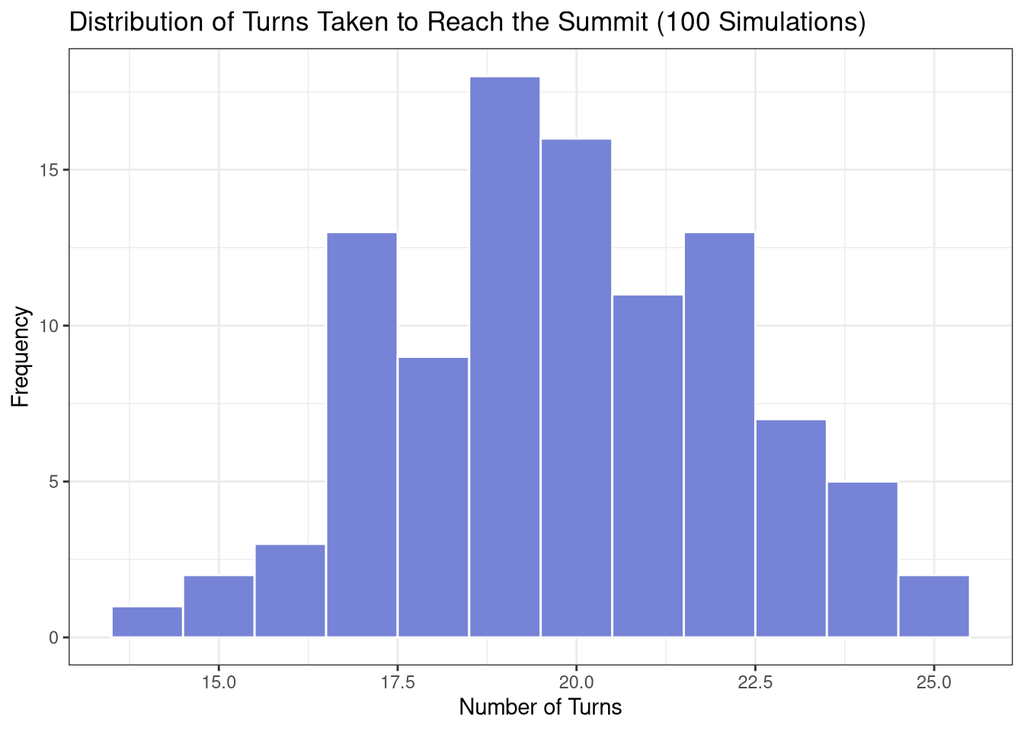

```r
#Create a data frame of the turns from all 100 simulation
turns_df <- data.frame(
  Turns = sim_res$turns_vector)

#Create histogram of turns taken across all simulations
ggplot(turns_df, aes(x = Turns)) +
  geom_histogram(binwidth = 1, fill = "#7683d6", colour = "white") +
  labs(
    title = "Distribution of Turns Taken to Reach the Summit (100 Simulations)",
    x = "Number of Turns",
    y = "Frequency"
  )
```

### Question 4, Position After Fixed Turns:

To investigate the typical position reached after a fixed number of turns, we create a new function, `simulate_pos_at()`, which simulates each game for a specified number of turns (`10` by default) and records the position reached after those turns. We first estimate the average position after 10 turns under the default parameters. We then repeat the simulation using a wider slip range (`4:8`) and a smaller climb reward (`2`) to examine how these changes affect player progress.

```r
#Test to demonstrate that simulate_pos_at() estimates the position reached after 10 turns

set.seed(123)

#Run 100 simulations and record the position reached after 10 turns
pos_res_default <- simulate_pos_at(
  n_simulations = 100, n_turns = 10
)

#Create a summary table of the position statistics
pos_table <- data.frame(
  Statistic = c("Mean", "Variance", "SD"),
  Value = round(as.numeric(pos_res_default$pos_stats), 2)
)

#Display table neatly for the knitted output
kable(
  pos_table,
  caption = "Summary Statistics for Player Position After 10 Turns (100 Simulations)",
  align = "c"
)
```

Summary Statistics for Player Position After 10 Turns (100 Simulations)

| Statistic | Value |
| --- | --- |
| Mean | 35.12 |
| Variance | 44.21 |
| SD | 6.65 |

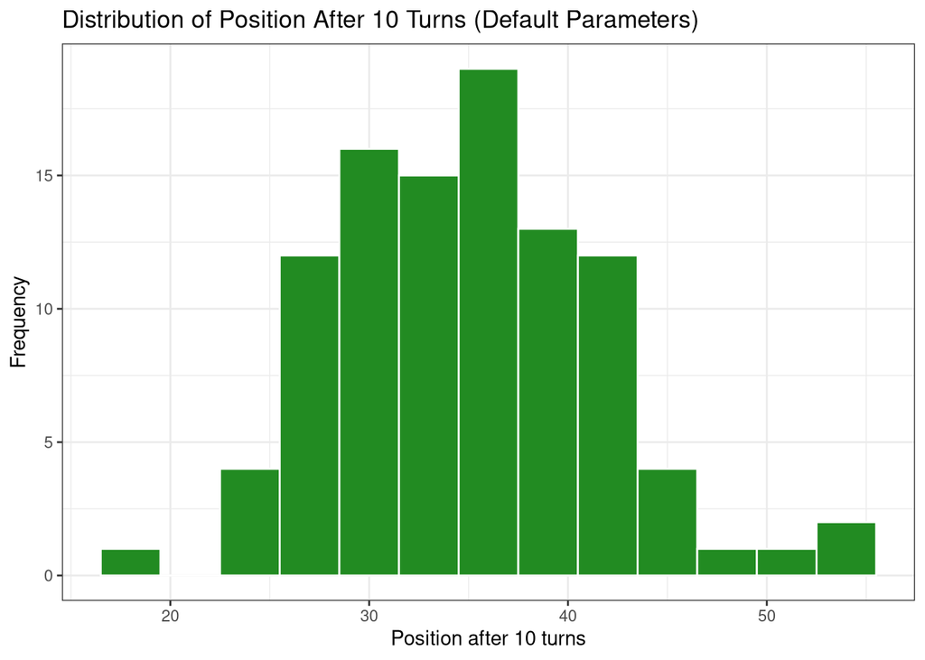

```r
#Create data frame for positions from all 100 simulations
df_pos_default <- data.frame(
  Position = pos_res_default$pos_vector)

#Plot a histogram of positions reached after 10 turns under default rules
ggplot(df_pos_default, aes(x = Position)) +
  geom_histogram(binwidth = 3, fill = "forestgreen", colour = "white") +
  labs(
    title = "Distribution of Position After 10 Turns (Default Parameters)",
    x = "Position after 10 turns",
    y = "Frequency"
  )
```

**Interpretation:**

Under the default rules, the average position after 10 turns is about `35` (mean = `35.12`, variance ≈ `44`), with most players finishing between positions `30 and 40`. When `slip_back_range` is increased to `4:8` and `climb_up_amount` is reduced to `2`, the average position drops to around `30` (mean = `29.58`) and the variance increases slightly (variance ≈ `50`). This occurs because players now slip back further and climb less per turn, reducing overall progress after the same number of turns.

```r
#Test to demonstrate how changing slip and climb rules affects position after 10 turns

set.seed(123)

#Run 100 simulations using a wider slip range and a smaller climb reward
pos_res_alt <- simulate_pos_at(
  n_simulations = 100,
  n_turns = 10,
  slip_back_range = 4:8,
  climb_up_amount = 2
)

#Create a summary table of the altered position statistics
pos_table_alt <- data.frame(
  Statistic = c("Mean", "Variance", "SD"),
  Value = round(as.numeric(pos_res_alt$pos_stats), 2)
)

#Display table neatly for the knitted output
kable(
  pos_table_alt,
  caption = "Summary Statistics for Position After 10 Turns (Adjusted Slip/Climb)",
  align = "c"
)
```

Summary Statistics for Position After 10 Turns (Adjusted Slip/Climb)

| Statistic | Value |
| --- | --- |
| Mean | 29.58 |
| Variance | 49.62 |
| SD | 7.04 |

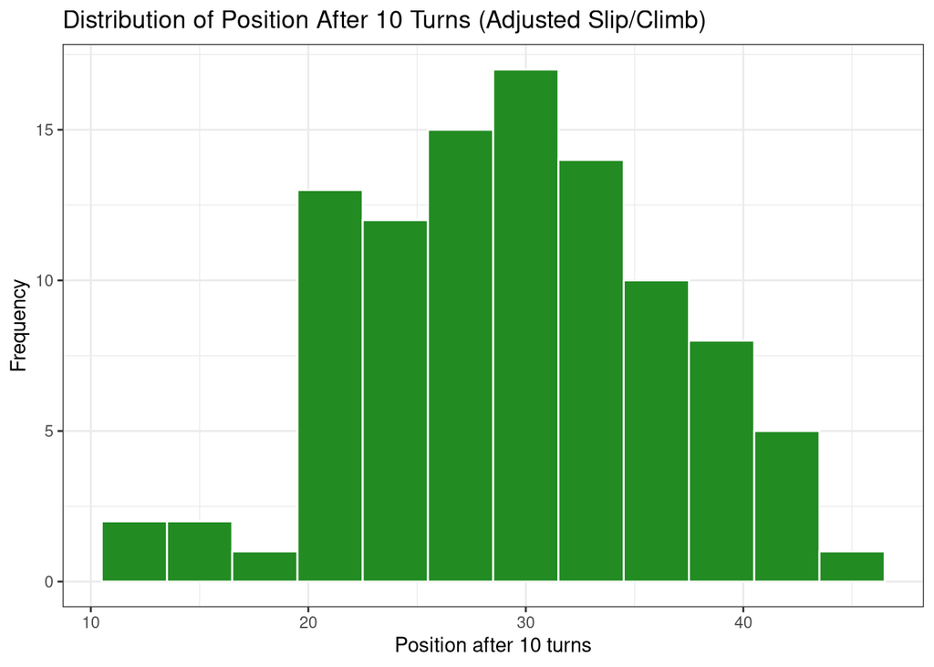

```r
#Create a data frame containing the positions from the altered simulations
df_pos_alt <- data.frame(
  Position = pos_res_alt$pos_vector)

#Plot a histogram of positions reached after 10 turns with adjusted slip/climb rules
ggplot(df_pos_alt, aes(x = Position)) +
  geom_histogram(binwidth =3, fill = "forestgreen", colour = "white") +
  labs(
    title = "Distribution of Position After 10 Turns (Adjusted Slip/Climb)",
    x = "Position after 10 turns",
    y = "Frequency"
  )
```

## **2 Data Analysis**

### Question 5, Code Review:

```r
#Load the dataset used throughout the analysis
load("data/assess_data_1225.Rdata")
#ERROR: file not found, tries to load from a non-existent subfolder "data/"
#FIX: use `load("assess_data_1225.Rdata")` if the file is in the working directory

#Create a density estimate of BMI for male patients
dens_m <- density(bmi_data$bmi[bmi_data$sex == "male"])

#Create a density estimate of BMI for female patients
dens_f <- density(bmi_data$bmi[bmi_data$sex == "female"])

#Plot the density curve for female BMI values in green
plot(dens_f, col = "green")

#Overlay the density curve for male BMI values on the same plot
lines(dens_m)
#(Optional improvement: add a legend to distinguish male vs female curves)

#Select the first 200 rows as a subset for PCA and regression
idx <- 1:200
#Works, but this is not a random subset and may introduce bias
#FIX: better practice would use a random sample, e.g. `idx <- sample(nrow(bmi_data), 200)`

#Perform PCA on numeric columns only (exclude 1 and 9 = id and sex), centring and scaling the variables
pca_res <- prcomp(bmi_data[idx, -c(1, 9)], center = TRUE, scale = TRUE)
#ERROR: the argument name in prcomp() is `scale.` not `scale`, so variables are not actually scaled here
#FIX: use `scale. = TRUE` instead of `scale = TRUE`

#Plot PC1 vs PC2 for the selected subset
plot(pca_res$x[, 1], pca_res$x[, 2], col = "blue", pch = 19)

#Fit a linear model of BMI on age using the subset 'idx'
out <- lm(bmi[idx] ~ age[idx])
#ERROR: bmi and age are not standalone objects; they are columns within bmi_data = can't be directly used this way
#FIX: reference them via the data frame: `out <- lm(bmi ~ age, data = bmi_data, subset = idx)`

#Display the summary statistics of the linear regression model
summary(out)

#Extract the p-value for the age coefficient from the model summary
p_val <- summary(out)$coefficients[2, 4]
```

If left uncorrected, these issues would lead to biased or unstable results. Addressing them ensures the analysis is statistically sound and reproducible.

## **2.1 Data Exploration**

### Question 6, BMI Quality Control:

A quality control procedure was applied to check the plausibility of BMI values, correct unrealistic measurements, and detect multivariate outliers using PCA. The corrected BMI values, PCA results, and final cleaned dataset used in later analyses are shown below.

**BMI QC Interpretation:**

The raw BMI values were inspected using sex-specific means and a boxplot. The original boxplot shows a large number of extreme BMI values in both sexes, including points close to 0 and above 300. These values fall far outside any physiologically reasonable range and confirm that the dataset contains implausible measurements requiring correction before analysis.

```r
#Keep original dataset for QC plots
bmi_original <- bmi_data

#Mean BMI by sex (original)
mean_bmi_original <- tapply(bmi_original$bmi, bmi_original$sex, mean, na.rm = TRUE)

#Create summary table for original BMI
original_bmi_summary <- data.frame(
  Sex = names(mean_bmi_original),
  Mean_BMI = as.numeric(mean_bmi_original)
)

#Display the table neatly
kable(
  original_bmi_summary,
  caption = "Mean BMI by Sex (Original Data)",
  align = "c"
)
```

Mean BMI by Sex (Original Data)

| Sex | Mean_BMI |
| --- | --- |
| female | 155.1213 |
| male | 171.5653 |

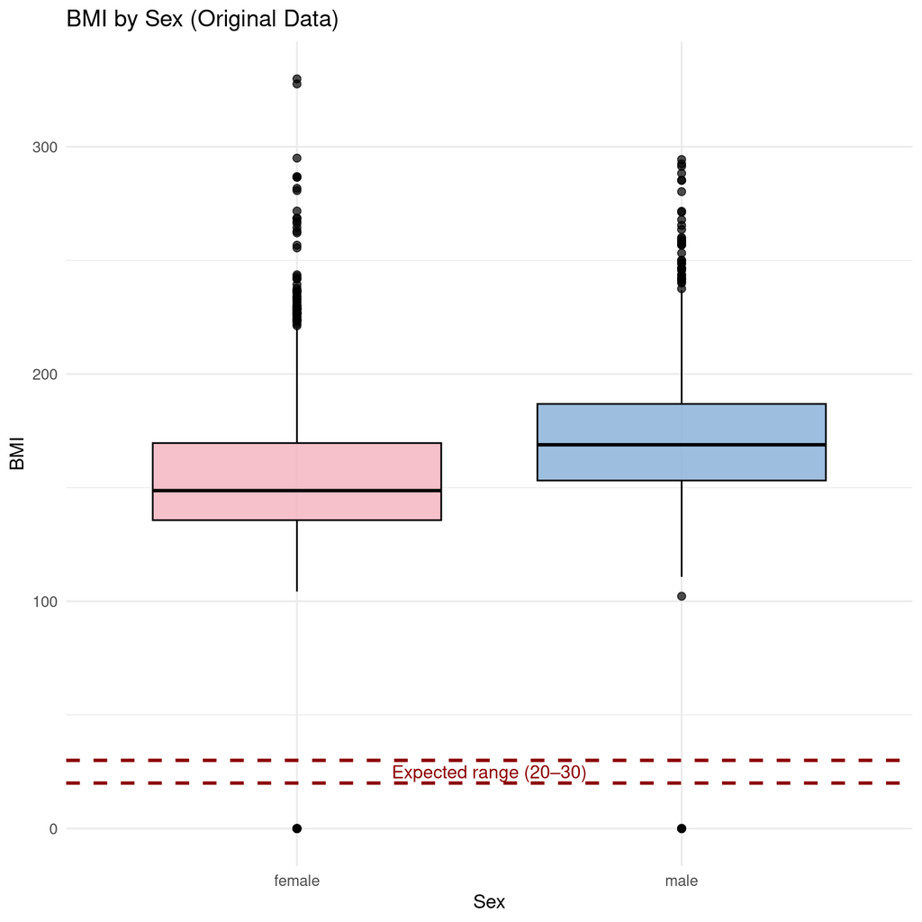

```r
#Original BMI Boxplot
ggplot(bmi_data, aes(x = sex, y = bmi, fill = sex)) +
  geom_boxplot(
    alpha = 0.85,
    colour = "black",
    #Bigger outlier dots for visualisation
    outlier.size = 2,
    outlier.alpha = 0.7
  ) +
  #Pink for female, blue for male
  scale_fill_manual(values = c(
    "female" = "#f4b6c2",
    "male"   = "#8cb3d9"
  )) +
  #Expected BMI range lines
  geom_hline(yintercept = 20, linetype = "dashed", colour = "darkred", linewidth = 1) +
  geom_hline(yintercept = 30, linetype = "dashed", colour = "darkred", linewidth = 1) +
  annotate("text",
           x = 1.5,
           y = 25,
           label = "Expected range (20–30)",
           colour = "darkred",
           size = 4) +
  labs(
    title = "BMI by Sex (Original Data)",
    x = "Sex",
    y = "BMI"
  ) +
  theme_minimal(base_size = 12) +
  theme(legend.position = "none")
```

```r
#Identify implausible BMI (<10 or >50)
bad_bmi_idx <- which(bmi_original$bmi < 10 | bmi_original$bmi > 50)
```

BMI values `below 10` or `above 50` were considered implausible and replaced using the standard BMI calculation (`weight / height^2`). After correction, the mean BMI for both sexes falls within the expected adult range of 20–30, and the corrected boxplot shows a much tighter, more realistic distribution. This confirms that the recalculated BMI values successfully addressed the extreme measurement errors present in the raw data.

```r
#Work on corrected copy of data (don't overwrite bmi_data)
bmi_qc <- bmi_original

#Recalculate BMI using weight and height (kg, cm)
bmi_recalc <- bmi_qc$weight / ((bmi_qc$height / 100)^2)

#Identify implausible BMI values (<10 or >50)
bad_bmi_idx <- which(bmi_qc$bmi < 10 | bmi_qc$bmi > 50)

#Apply corrected BMI where needed
bmi_qc$bmi[bad_bmi_idx] <- bmi_recalc[bad_bmi_idx]

#Mean BMI by sex (after correction)
mean_bmi_sex <- tapply(bmi_qc$bmi, bmi_qc$sex, mean, na.rm = TRUE)

#Summary table for cleaned mean BMI by sex
bmi_summary <- data.frame(
  Sex = names(mean_bmi_sex),
  Mean_BMI = as.numeric(mean_bmi_sex)
)

#Display as neat table for HTML doc
kable(
  bmi_summary,
  caption = "Mean BMI by Sex after BMI Correction",
  align   = c("c", "c")
)
```

Mean BMI by Sex after BMI Correction

| Sex | Mean_BMI |
| --- | --- |
| female | 24.12762 |
| male | 26.66493 |

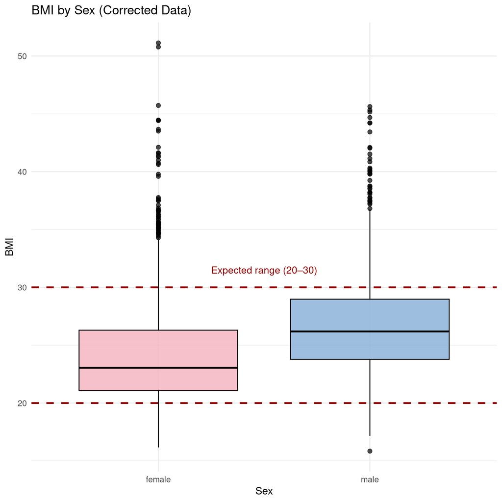

```r
#Corrected BMI Boxplot
ggplot(bmi_qc, aes(x = sex, y = bmi, fill = sex)) +
  geom_boxplot(
    alpha = 0.85,
    colour = "black",
    #Bigger outlier dots for visualisation
    outlier.size = 2,
    outlier.alpha = 0.7
  ) +
  #Pink for female, blue for male
  scale_fill_manual(values = c(
    "female" = "#f4b6c2",
    "male"   = "#8cb3d9"
  )) +
  #Expected BMI range lines
  geom_hline(yintercept = 20, linetype = "dashed", colour = "darkred", linewidth = 1) +
  geom_hline(yintercept = 30, linetype = "dashed", colour = "darkred", linewidth = 1) +
  annotate("text",
           #Move annotation above the dotted lines to avoid overlap with the boxplots
           x = 1.5,
           y = 31.5,
           label = "Expected range (20–30)",
           colour = "darkred",
           size = 4) +
  labs(
    title = "BMI by Sex (Corrected Data)",
    x = "Sex",
    y = "BMI"
  ) +
  theme_minimal(base_size = 12) +
  theme(legend.position = "none")
```

**PCA Interpretation**

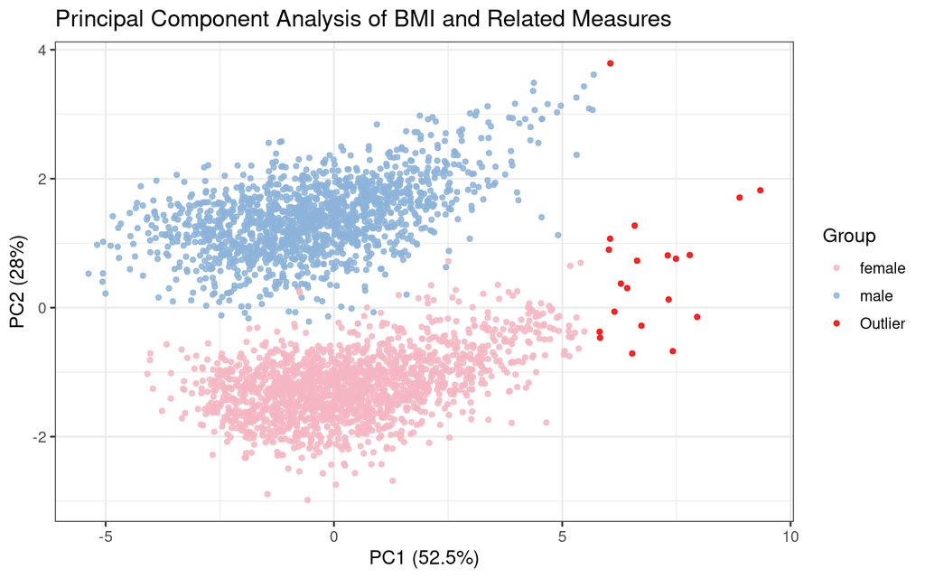

```r
#Select numeric variables for PCA (exclude categorical columns)
num_cols <- c("age", "bai", "bmi", "body_fat", "density", "weight", "height")

#Subset complete numeric cases
complete_idx <- complete.cases(bmi_qc[, num_cols])
bmi_num <- bmi_qc[complete_idx, num_cols]

#Run PCA on numeric variables
pca <- prcomp(bmi_num, center = TRUE, scale. = TRUE)
pca_summary <- summary(pca)

#Extract PCA scores for each sample
pca_df <- data.frame(pca$x)

#Add the sex label back for plotting (only for complete rows)
pca_df$Sex <- bmi_qc$sex[complete_idx]

#Compute z-scores for PC1 and PC2 to quantify deviation from mean
pca_df$PC1_z <- as.numeric(scale(pca_df$PC1))
pca_df$PC2_z <- as.numeric(scale(pca_df$PC2))

#Highlight potential outliers using the 3 SD rule on PC1 or PC2
pca_df$Group <- ifelse(
  abs(pca_df$PC1_z) > 3 | abs(pca_df$PC2_z) > 3,
  "Outlier",
  as.character(pca_df$Sex)
)

#PCA scatter plot coloured by sex
ggplot(pca_df, aes(x = PC1, y = PC2, colour = Group)) +
  geom_point(size = 1.2, alpha = 0.85) +
  scale_colour_manual(
    values = c(
      "female"  = "#f4b6c2",
      "male"    = "#8cb3d9",
      #Outliers highlighted in red
      "Outlier" = "red"
    )
  ) +
  labs(
    title  = "Principal Component Analysis of BMI and Related Measures",
    x = paste0("PC1 (", round(100 * pca_summary$importance[2, 1], 1), "%)"),
    y = paste0("PC2 (", round(100 * pca_summary$importance[2, 2], 1), "%)"),
    colour = "Group"
  ) +
  theme_bw(base_size = 12)
```

The PCA plot summarises major sources of variation across the cleaned numeric variables and shows two clear clusters for male and female participants, with most samples grouped closely. A small set of points sits far to the right of the main clusters. These were identified as multivariate outliers using a `>3` standard deviation threshold on PC1 or PC2. These outlier samples are likely due to measurement error. Removing them reduces noise and prevents extreme values from affecting the regression analyses in Questions 7 and 8.

**Output from the update_bmi() Function**

```r
#Apply BMI QC function to create cleaned dataset
bmi_clean <- update_bmi(bmi_data)

#Ensure sex is stored as a factor for later regression models
bmi_clean$sex <- factor(bmi_clean$sex)

#Check dimensions of final cleaned data
dim(bmi_clean)
```

```
## [1] 3180    9
```

After applying the `update_bmi()` function, implausible BMI values were corrected and PCA outliers were removed. The resulting cleaned dataset (bmi_clean, `3,180 rows × 9 variables`) was used for all regression analyses in Questions 7 and 8.

**QC Summary Interpretation:**

```r
#Create a summary of row counts at each QC step

#Number of rows in original dataset
rows_original <- nrow(bmi_data)

#Rows after correcting implausible BMI
rows_after_bmi <- nrow(bmi_qc)

#Rows after removing PCA outliers
rows_final <- nrow(bmi_clean)

#Combine row counts into a summary table
qc_summary <- data.frame(
  Step = c("Original dataset",
           "After BMI correction",
           "After PCA outlier removal"),
  Rows = c(rows_original,
           rows_after_bmi,
           rows_final)
)

#Display the table neatly
kable(
  qc_summary,
  caption = "Summary of Row Counts at Each Stage of Quality Control",
  align = "c"
)
```

Summary of Row Counts at Each Stage of Quality Control

| Step | Rows |
| --- | --- |
| Original dataset | 3200 |
| After BMI correction | 3200 |
| After PCA outlier removal | 3180 |

The dataset initially contained `3,200` observations. BMI correction did not remove any rows, as implausible values were recalculated rather than discarded. PCA outlier detection identified `20` multivariate outliers, which were removed to produce the final cleaned dataset of `3,180` rows. Removing them improves data homogeneity and ensures more reliable regression results in subsequent questions.

## **2.2 Regression Analysis**

### Question 7, Simple Linear Regression:

A simple linear regression model was fitted to evaluate the relationship between BMI and body fat (%). The results and diagnostic plots are shown below.

**Linear Regression Model Interpretation:**

The fitted model shows a clear positive association between BMI and body fat. The estimated slope (`β₁ ≈ 0.95`) indicates that, on average, each one unit increase in BMI is associated with roughly a one percentage point increase in body fat. BMI is highly statistically significant (`p < 2 × 10⁻¹⁶`), providing strong evidence for a linear relationship between the two variables.

```r
#Fit simple linear regression model
ls_fit <- lm(body_fat ~ bmi, data = bmi_clean)

#Show model summary
summary(ls_fit)
```

```
##
## Call:
## lm(formula = body_fat ~ bmi, data = bmi_clean)
##
## Residuals:
##     Min      1Q  Median      3Q     Max
## -19.870  -5.116   0.120   5.617  25.920
##
## Coefficients:
##             Estimate Std. Error t value Pr(>|t|)
## (Intercept)  3.94953    0.70837   5.575 2.68e-08 ***
## bmi          0.94779    0.02771  34.208  < 2e-16 ***
## ---
## Signif. codes:  0 '***' 0.001 '**' 0.01 '*' 0.05 '.' 0.1 ' ' 1
##
## Residual standard error: 6.863 on 3168 degrees of freedom
##   (10 observations deleted due to missingness)
## Multiple R-squared:  0.2697, Adjusted R-squared:  0.2695
## F-statistic:  1170 on 1 and 3168 DF,  p-value: < 2.2e-16
```

However, the model explains only around `27%` of the variation in body fat (`R² = 0.27`). This suggests that although BMI is a relevant predictor, most of the variability is driven by additional physiological or demographic factors that are not captured in a single-predictor model.

**Scatter Plot Interpretation:**

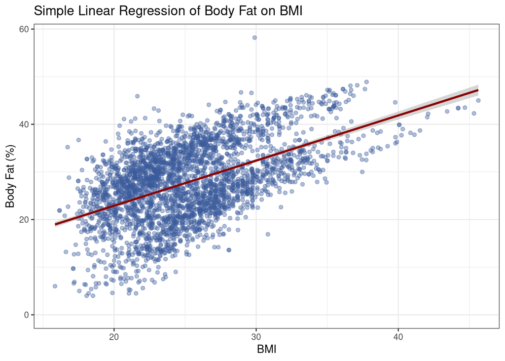

```r
#Scatterplot of body fat vs BMI with fitted regression line
ggplot(bmi_clean, aes(x = bmi, y = body_fat)) +

  #Plot raw data points (semi-transparent for overlap)
  geom_point(alpha = 0.4, colour = "#3b5a9b") +

  #Add fitted simple linear regression line
  geom_smooth(method = "lm", se = TRUE, colour = "darkred", linewidth = 1) +
  labs(
    title = "Simple Linear Regression of Body Fat on BMI",
    x = "BMI",
    y = "Body Fat (%)"
  )
```

**Residual Diagnostics Overview:**

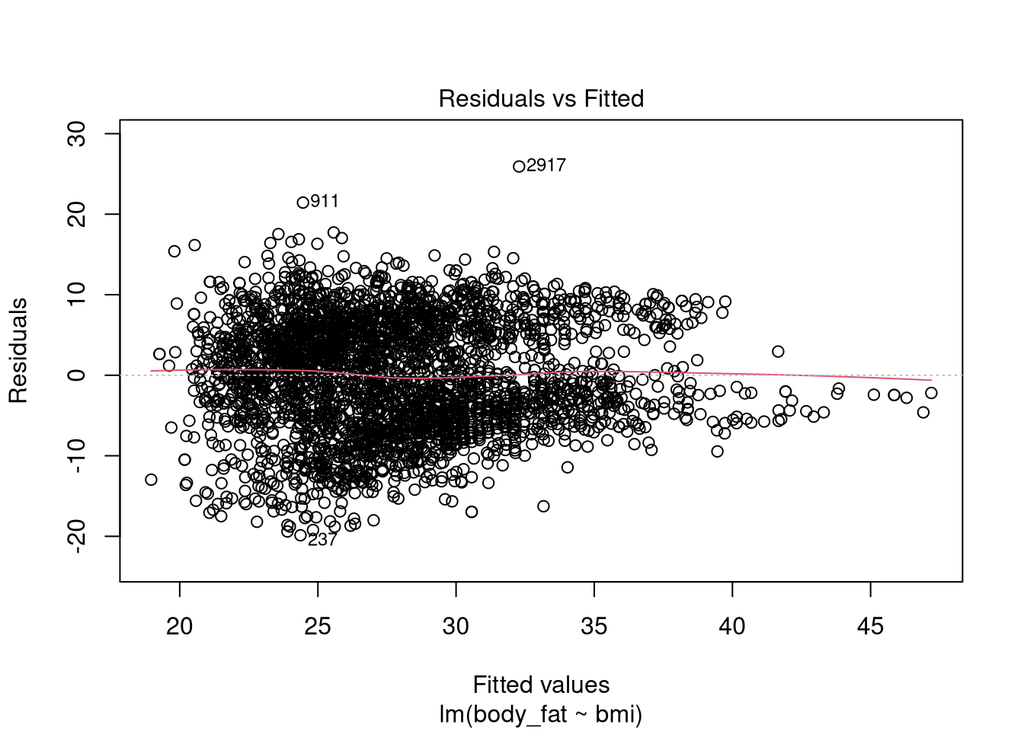

```r
#Extract residuals
ls_residual <- residuals(ls_fit)

#Residuals vs Fitted (checks linearity + constant variance)
plot(ls_fit, 1)
```

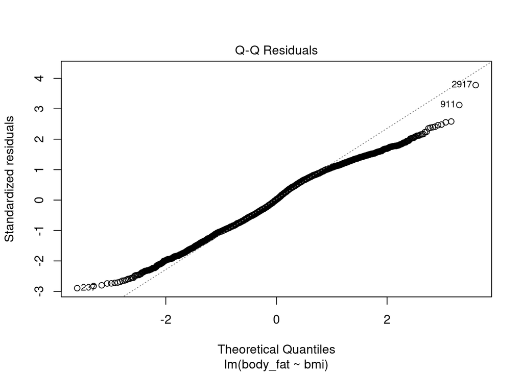

```r
#Q–Q Plot (checks normality of residuals)
plot(ls_fit, 2)
```

### Question 8, Multiple Linear Regression:

A multiple linear regression model incorporating age, BMI, BAI, density, weight, height, and sex was used to assess their combined ability to predict body fat (%). The full model and diagnostic plots are shown below.

**Multiple Regression Model Interpretation:**

```r
#Fit multiple linear regression model for body fat
ml_fit <- lm(
  body_fat ~ age + bmi + bai + density + weight + height + sex,
  data = bmi_clean
)

#Display model summary with coefficient significance
summary(ml_fit)
```

```
##
## Call:
## lm(formula = body_fat ~ age + bmi + bai + density + weight +
##     height + sex, data = bmi_clean)
##
## Residuals:
##     Min      1Q  Median      3Q     Max
## -1.6679 -0.3242 -0.0032  0.3264  1.7947
##
## Coefficients:
##               Estimate Std. Error  t value Pr(>|t|)
## (Intercept)  5.432e+02  2.113e+00  257.076  < 2e-16 ***
## age          4.760e-04  8.675e-04    0.549 0.583202
## bmi          9.752e-03  3.300e-02    0.296 0.767601
## bai          1.162e-02  3.388e-03    3.428 0.000615 ***
## density     -4.942e+02  1.055e+00 -468.246  < 2e-16 ***
## weight       3.212e-06  1.184e-02    0.000 0.999784
## height      -1.897e-03  1.080e-02   -0.176 0.860509
## sexmale     -4.815e-02  5.672e-02   -0.849 0.395977
## ---
## Signif. codes:  0 '***' 0.001 '**' 0.01 '*' 0.05 '.' 0.1 ' ' 1
##
## Residual standard error: 0.4902 on 3162 degrees of freedom
##   (10 observations deleted due to missingness)
## Multiple R-squared:  0.9963, Adjusted R-squared:  0.9963
## F-statistic: 1.21e+05 on 7 and 3162 DF,  p-value: < 2.2e-16
```

In the multiple regression model, body fat is modelled as a function of age, BMI, BAI, density, weight, height and sex. The overall model fit is extremely high (`R² ≈ 0.9963`), indicating that the covariates collectively explain almost all of the variation in body fat. Density is by far the dominant predictor (large negative coefficient with `p < 2 × 10⁻¹⁶`), and BAI also remains statistically significant (`p < 0.001`). Once density and BAI are included, BMI, age, weight, height, and sex are no longer significant, suggesting that density already explains most of the variation these variables would contribute.

**Scatterplot Interpretation:**

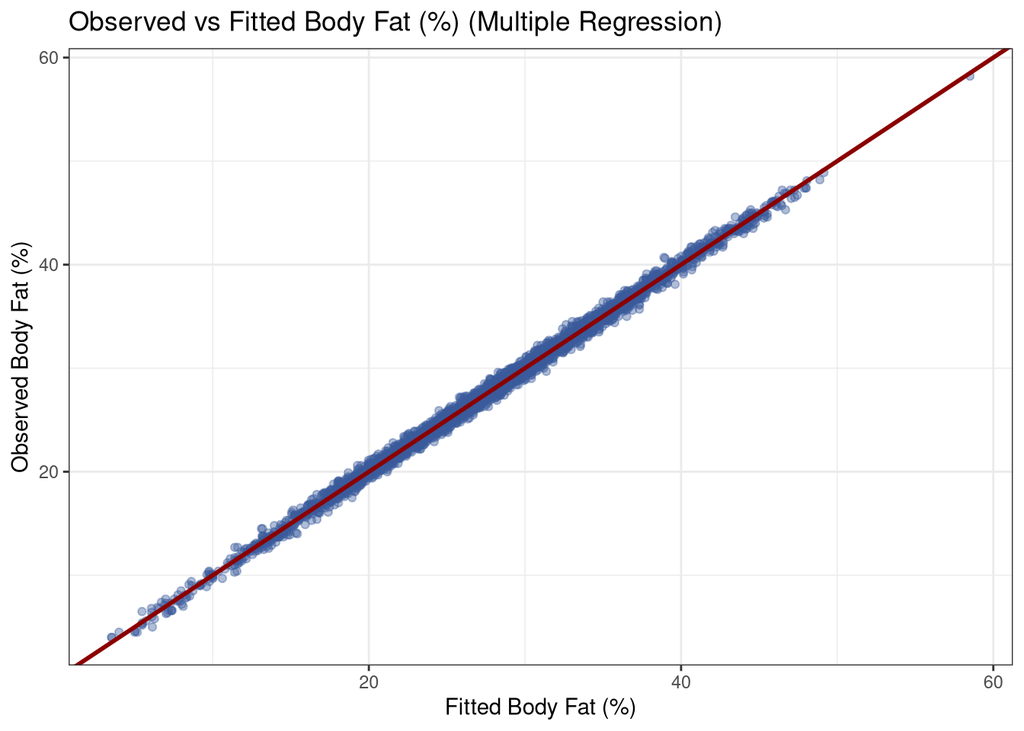

```r
#Create a data frame for plotting observed vs fitted body fat values
multi_fit_df <- data.frame(
  Fitted = fitted(ml_fit),
  Observed = ml_fit$model$body_fat
)

#Scatterplot comparing observed and fitted values
ggplot(multi_fit_df, aes(x = Fitted, y = Observed)) +
  geom_point(alpha = 0.4, colour = "#3b5a9b") +
  geom_abline(intercept = 0, slope = 1, #Add 1:1 reference line
              colour = "darkred", linewidth = 1) +
  labs(
    title = "Observed vs Fitted Body Fat (%) (Multiple Regression)",
    x = "Fitted Body Fat (%)",
    y = "Observed Body Fat (%)"
  )
```

The observed-versus-fitted scatter plot shows points lying almost exactly on the 1:1 reference line, indicating that the multiple regression model predicts body fat with very high accuracy. This is consistent with the model’s `R² of 0.9963` and suggests that the included covariates capture nearly all of the variability in body fat.

**Residual Diagnostics Overview:**

In the residuals-versus-fitted plot, the residuals are tightly centred around zero with no visible pattern, indicating that the linearity assumption is satisfied. The spread remains fairly constant across fitted values, suggesting that the constant-variance assumption holds much better than in the simple regression model. A few mild outliers appear, but none are influential. Overall, the plot indicates that the multiple regression model provides a good fit.

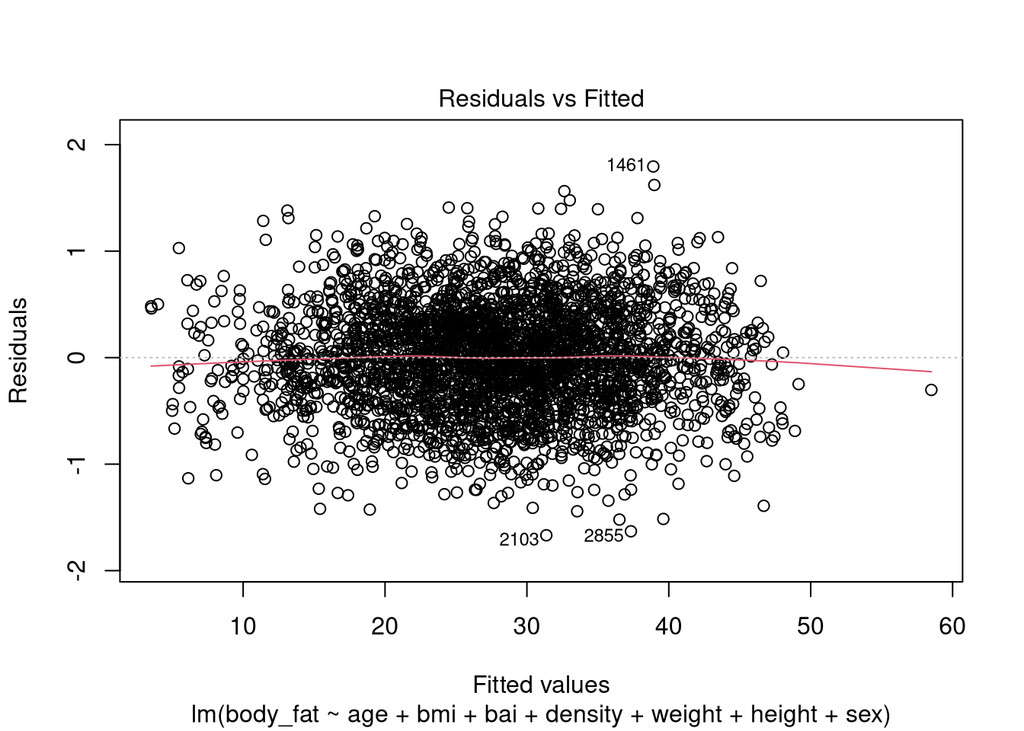

```r
#Extract residuals
ml_residual <- residuals(ml_fit)

#Residuals vs Fitted (checks linearity + constant variance)
plot(ml_fit, 1)
```

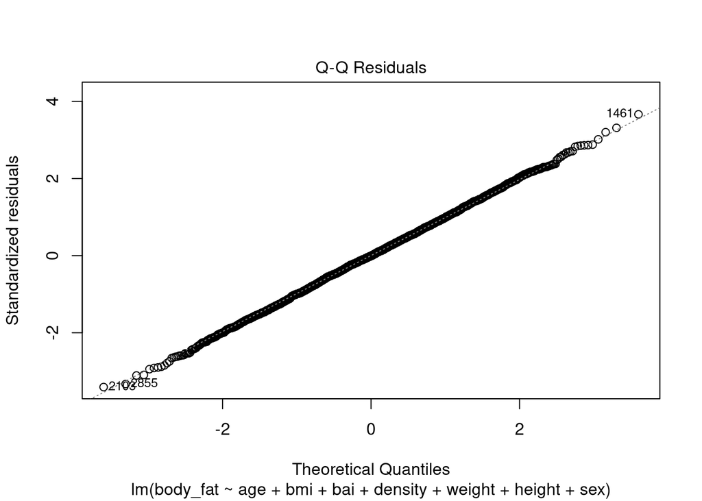

```r
#Q–Q Plot (checks normality of residuals)
plot(ml_fit, 2)
```

The Q–Q plot shows residuals lying very close to the reference line, with only minor deviations in the extreme tails. This indicates that the normality assumption is well satisfied. Compared with the simple BMI-only model, the multiple regression model provides a much better approximation to normally distributed errors and captures the underlying structure of the data more effectively.

## Disclaimer

ChatGPT was used only to troubleshoot minor coding errors, confirm that my functions met the requirements of each question, and assist with small HTML formatting improvements. All written explanations were carried out independently. Below are examples of the prompts and brief outputs used:

1. Prompt: “Why is my PCA not scaling? I wrote `prcomp(data, scale = TRUE)` but it doesn’t seem to work.”

Response: “In `prcomp()`, the correct argument is scale. rather than scale. Use `prcomp(data, center = TRUE, scale. = TRUE)` to ensure variables are standardised.”

2. Prompt: “I am getting a ggplot warning about `..density..` being deprecated. Do I need to fix this?”

Response: “This warning is harmless. The histogram will still render correctly. You can optionally replace `..density..` with `after_stat(density)`, but it is not required.”

3. Prompt: “My `play_mc()` function always returns 70 even on the first move. What is wrong?”

Response: “You have the line `if (pos < 70) { pos <- 70 }`, which forces every move to the summit. Replace it with `pos <- start_pos + die` and apply slide/climb rules afterward.”

4. Prompt: “Do I need to explicitly write `n_simulations = 100` and `n_turns = 10` if they’re already the defaults?”

Response: “The function will work without specifying them, but including the values makes your code clearer to the marker and shows you are intentionally using the required settings.”

5. Prompt: “How can I display my summary tables neatly in the knitted HTML document? I get marked on presentation.”

Response: “`kable()` is a good choice for clean HTML tables. You can format your table by writing:

kable(your_table, caption = “Summary Statistics”, align = “c”)

This will centre the columns and produce a clear, readable table in the HTML output. You do not need additional styling unless you want to customise the appearance further.”

6. Prompt: “What thresholds should I use to flag implausible BMI values for adults in this dataset?”

Response: “Typical adult BMI values cluster around 20–30, so values very close to 0 or in the hundreds almost certainly reflect data entry or unit errors rather than real measurements. As a pragmatic QC rule, you can treat BMI values < 10 or > 50 as implausible and recalculate them using the standard formula from weight and height, while still allowing realistic high-BMI individuals to remain in the dataset.”